# Bayesian ANOVA (Analysis of Variance)

Simon Thornewill von Essen

28 1 2020

In this file, we will be investigating how to implement an ANOVA

To do this, we will have a look at the `PlantGrowth` dataset in R. This dataset contains the results from an experiment that compares weights of plants under a control and two treatment conditions.

```r
# Import Data
data("PlantGrowth")

head(PlantGrowth, 3)
```

```
##   weight group
## 1   4.17  ctrl
## 2   5.58  ctrl
## 3   5.18  ctrl
```

Before we do any modeling, it’s always good to have a look at our data. I will be plotting this using `ggplot2` because I want more practice using it.

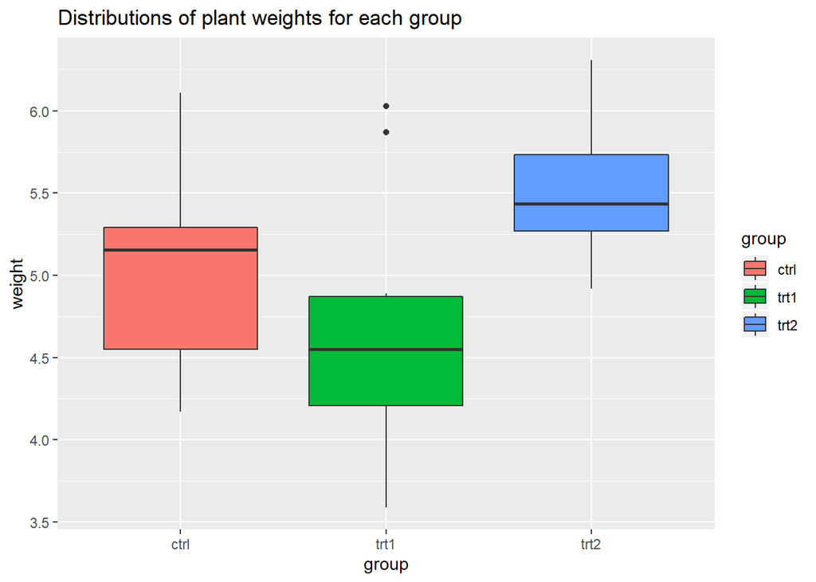

```r
# Visualise
ggplot(data = PlantGrowth, aes(x=group, y=weight, fill=group)) +
  geom_boxplot() +
  ggtitle("Distributions of plant weights for each group")
```

We can see that for the two treatments, the first one made the weights lower overall and the second treatment seems to make the weights higher. But you don’t know for sure until you do some statistics.

Before we begin modeling, it’s also usually a good idea to have a reference analysis to compare with. We can use this using the `lm` function in R.

```r
lmod <- lm(weight ~ group, data=PlantGrowth)

summary(lmod)
```

```
##
## Call:
## lm(formula = weight ~ group, data = PlantGrowth)
##
## Residuals:
##     Min      1Q  Median      3Q     Max
## -1.0710 -0.4180 -0.0060  0.2627  1.3690
##
## Coefficients:
##             Estimate Std. Error t value Pr(>|t|)
## (Intercept)   5.0320     0.1971  25.527   <2e-16 ***
## grouptrt1    -0.3710     0.2788  -1.331   0.1944
## grouptrt2     0.4940     0.2788   1.772   0.0877 .
## ---
## Signif. codes:  0 '***' 0.001 '**' 0.01 '*' 0.05 '.' 0.1 ' ' 1
##
## Residual standard error: 0.6234 on 27 degrees of freedom
## Multiple R-squared:  0.2641, Adjusted R-squared:  0.2096
## F-statistic: 4.846 on 2 and 27 DF,  p-value: 0.01591
```

We can also have a look at the ANOVA table for this dataset.

```r
anova(lmod)
```

```
## Analysis of Variance Table
##
## Response: weight
##           Df  Sum Sq Mean Sq F value  Pr(>F)
## group      2  3.7663  1.8832  4.8461 0.01591 *
## Residuals 27 10.4921  0.3886
## ---
## Signif. codes:  0 '***' 0.001 '**' 0.01 '*' 0.05 '.' 0.1 ' ' 1
```

Here, we have the result of the statistical test for each (in this case only one) factor in a dataset and whether this factor contributes a lot to the to the varaibility in the data. (I.e. comparing the variability inside of the group vs outside.)

In this case we get a p-value of beneath 0.05, so we can say that it is marginally significant.

## Building ANOVA in JAGS

Now that we’ve done some basic analysis, let’s try and build this in R.

```r
mod_string = " model {
    for (i in 1:length(y)) {
        y[i] ~ dnorm(mu[grp[i]], prec)
    }

    for (j in 1:3) {
        mu[j] ~ dnorm(0.0, 1.0/1.0e6)
    }

    prec ~ dgamma(5/2.0, 5*1.0/2.0)
    sig = sqrt( 1.0 / prec )
} "

data_jags <- list(y=PlantGrowth$weight,
              grp=as.numeric(PlantGrowth$group))

params <- c("mu", "sig")

inits = function() {
    inits = list("mu"=rnorm(3,0.0,100.0), "prec"=rgamma(1,1.0,1.0))
}

mod <- jags.model(textConnection(mod_string), data=data_jags, inits=inits, n.chains=3)
```

Now that our model is initialised, we can update it.

[figure not shown]

```r
update(mod, 1e3)


mod_sim <- coda.samples(model = mod,
                        variable.names = params,
                        n.iter = 5e3)

plot(mod_sim)
```

We can have a look at our trace plots to see if our model has converged, I would say that this isn’t looking too bad.

Next, let’s have a look at our gelman stats.

```r
gelman.diag(mod_sim)
```

```
## Potential scale reduction factors:
##
##       Point est. Upper C.I.
## mu[1]          1          1
## mu[2]          1          1
## mu[3]          1          1
## sig            1          1
##
## Multivariate psrf
##
## 1
```

This is further proof that we have converged and no thinning or anything like that is necessary.

```r
autocorr.diag(mod_sim)
```

```
##              mu[1]        mu[2]        mu[3]          sig
## Lag 0   1.00000000  1.000000000  1.000000000  1.000000000
## Lag 1  -0.01086786 -0.005722080 -0.002120834  0.077709342
## Lag 5  -0.01130947  0.004449923 -0.006856719 -0.006669757
## Lag 10  0.02343970 -0.003107911  0.004145382  0.002617869
## Lag 50 -0.01600601 -0.003210008 -0.002077229  0.007854370
```

It also looks like autocorrelation isn’t a big deal either.

```r
effectiveSize(mod_sim)
```

```
##    mu[1]    mu[2]    mu[3]      sig
## 15884.56 15000.00 15000.00 12834.32
```

The effective sample size is also pretty good, the only value that maybe gives some “concern” is the sigma value.

We can compare our posterior means with the reference we got from our analysis earlier.

```r
mod_csim <- as.mcmc(do.call(rbind, mod_sim))

pm_params <- colMeans(mod_csim)

pm_params
```

```
##     mu[1]     mu[2]     mu[3]       sig
## 5.0294011 4.6600639 5.5260153 0.7132259
```

```r
coefficients(lmod)
```

```
## (Intercept)   grouptrt1   grouptrt2
##       5.032      -0.371       0.494
```

These results are consistent. (Note that you need to add the coeffs together to get the posterior prediction.)

Now let’s try to calculate residuals:

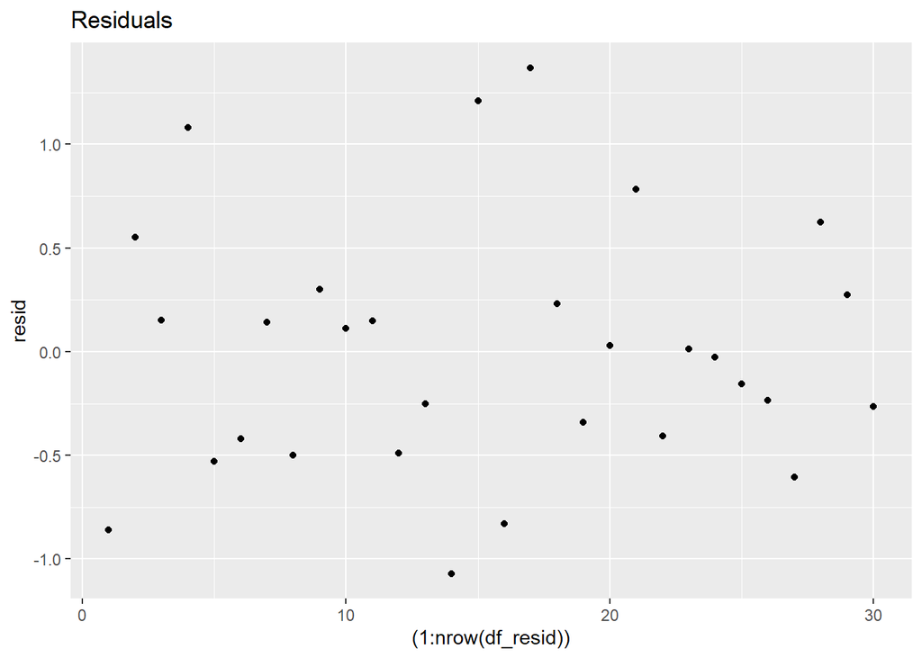

```r
yhat <- pm_params[1:3][data_jags$grp]
resid <- data_jags$y - yhat

df_resid <- data.frame(yhat=yhat, resid=resid, y=data_jags$y, cat=factor(data_jags$grp))

ggplot(data = df_resid, aes(x=(1:nrow(df_resid)), y=resid)) +
  geom_point() +
  ggtitle("Residuals")
```

There doesnt seem to be a long term trend in the residuals which is good.

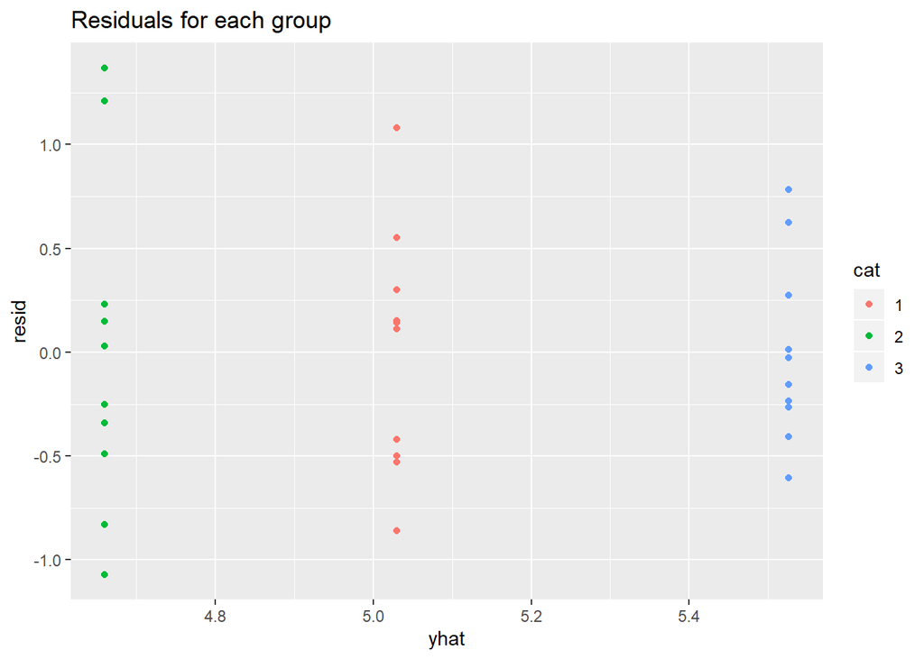

```r
ggplot(data = df_resid, aes(x=yhat, y=resid)) +
  geom_point(aes(color=cat)) +
  ggtitle("Residuals for each group")
```

Its worth noting that the residual variance for category 2 is much larger than that for category 2, despite having lower predicted values. This is why having a separate parameter for variance might be a good idea.

Now, let’s have a look at our summary of the posterior distribuion.

```r
summary(mod_sim)
```

```
##
## Iterations = 1001:6000
## Thinning interval = 1
## Number of chains = 3
## Sample size per chain = 5000
##
## 1. Empirical mean and standard deviation for each variable,
##    plus standard error of the mean:
##
##         Mean      SD  Naive SE Time-series SE
## mu[1] 5.0294 0.22800 0.0018616       0.001815
## mu[2] 4.6601 0.22819 0.0018631       0.001863
## mu[3] 5.5260 0.22573 0.0018431       0.001843
## sig   0.7132 0.09244 0.0007547       0.000816
##
## 2. Quantiles for each variable:
##
##         2.5%    25%    50%    75%  97.5%
## mu[1] 4.5764 4.8807 5.0303 5.1810 5.4740
## mu[2] 4.2136 4.5100 4.6615 4.8090 5.1129
## mu[3] 5.0881 5.3739 5.5246 5.6748 5.9766
## sig   0.5587 0.6474 0.7043 0.7678 0.9218
```

We can also have a look at our HPD interval

```r
HPDinterval(mod_csim)
```

```
##           lower    upper
## mu[1] 4.5838158 5.477434
## mu[2] 4.2109401 5.108722
## mu[3] 5.0968144 5.984201
## sig   0.5476284 0.901038
## attr(,"Probability")
## [1] 0.95
```

Whats the probability that it is better given the data?

```r
mean(mod_csim[,3] > mod_csim[,1])
```

```
## [1] 0.9364667
```

Seems like it’s roughly 94%.

What about if this treatment would be costly?, say, 10% more. What percent is bigger than that difference?

```r
mean(mod_csim[,3] > 1.1*mod_csim[,1])
```

```
## [1] 0.492
```

Note: it’s best not to explore your data for hypothesis because it can lead to false-positives. Best to have an idea about what questions you want answered *before* your analysis.